# Real-Time Retail Feedback Intelligence

## **Section 7: Applying GenAI for Product Recommendation:**

Now, let's use the model for a different task: predicting the Recommended IND flag.

**Questions:**

1. How do you design a prompt that strictly asks for a binary output (1 or 0) and a brief reason?
2. What kind of function is needed to reliably parse the model's text response to extract the 1/0 flag and the Reason?
3. How do you evaluate the model's performance as a classifier using standard metrics like accuracy, confusion matrix, and classification report?

**How the Process Works**

**1. Prepare Data**

Copy the dataset, store the original recommendation labels, and remove them from the model input to avoid leakage.

**2. Generate Predictions**

Use a strict two-line prompt to make the LLM output a binary recommendation (1/0) and a short reason based only on the review text.

**3. Parse Outputs**

Extract the flag and reason from the raw LLM response using regex-based parsing that handles formatting issues.

**4. Build Prediction Table**

Run the prompt for each review, parse the result, and store the predictions in a new DataFrame.

**5. Evaluate Performance**

Compare LLM predictions with true labels using accuracy, confusion matrix, and classification report.

**6. Explain Mismatches**

For incorrect predictions, generate a short explanation describing why the model’s decision may have differed from the human label.

```python
# --- Predicting Product Recommendations ---
# Step 1: Prepare the data
# Copy the sample DataFrame to avoid modifying the original
# Store the actual labels in a new column 'Actual_Recommended'
# Drop the original 'Recommended.IND' column to prevent the LLM from seeing it
# This simulates a real scenario where we only have the review text

# Fixed: Use 'df_sample_copy' instead of the undefined 'df_sample'
df_reco = df_sample_copy.copy()
df_reco["Actual_Recommended"] = df_reco["Recommended.IND"]
df_reco = df_reco.drop(columns=["Recommended.IND"])
print(f'Recommendation distribution: {df_reco["Actual_Recommended"].value_counts().to_dict()}')
```

```
Recommendation distribution: {1: 40, 0: 10}
```

```python
# Step 2: Define the recommendation prediction prompt
# This prompt is designed to force a strict binary output format:
# - Line 1: "Recommended: 1" or "Recommended: 0"
# - Line 2: "Reason: [brief explanation]"
# The strict format ensures reliable regex parsing of the response.
recommendation_prompt = '''
TASK: Binary product recommendation prediction.

Based exclusively on the customer review below, output EXACTLY two lines:
Line 1: Recommended: [1 or 0]  (1=would recommend, 0=would not recommend)
Line 2: Reason: [One specific sentence citing evidence from the review]

DECISION RULES:
- Output 1 if: review contains words like 'love', 'perfect', 'great', 'will buy again',
               'recommend', 'obsessed', 'flattering', 'true to size'
- Output 0 if: review contains words like 'return', 'disappointed', 'poor quality',
               'doesn't fit', 'never again', 'waste of money', 'not as described'
- If ambiguous: use the RATING context in the review to decide (positive tone = 1)

DO NOT output anything else. No preamble, no explanation beyond the 2 lines.
'''
```

```python
# Step 3: Parse the LLM's response and generate predictions
# parse_recommendation_reply() extracts the binary flag and reason from the raw text
# using regex patterns to handle formatting variations in the LLM's output

def parse_recommendation_reply(raw_text):
    if raw_text is None: return (np.nan, "", "")
    s = str(raw_text).strip()
    # Look for "Recommended: 0" or "Recommended: 1" in the response
    m = re.search(r'Recommended\s*:\s*([01])\b', s, re.IGNORECASE)
    flag = int(m.group(1)) if m else np.nan
    # Look for "Reason: ..." in the response
    m3 = re.search(r'Reason\s*:\s*(.+)', s, re.IGNORECASE)
    reason = m3.group(1).strip() if m3 else ""
    return (flag, reason[:200], s)

# Generate predictions for all 50 reviews
llm_preds = []
for review in tqdm(df_reco["Review.Text"], desc="LLM Recommend Predictions"):
    # Ensure review is a string, handling potential np.nan values
    review_content = str(review) if pd.notna(review) else ""
    prompt = recommendation_prompt + "\n\nReview:\n" + review_content
    try:
        resp = client.chat.completions.create(
            model=model_name,
            messages=[{"role":"user", "content": prompt}],
            temperature=0.0, max_tokens=60
        )
        raw = resp.choices[0].message.content or ""
    except Exception as e:
        raw = f"""ERROR: {type(e).__name__}: {e}

Review causing error: {review_content}"""

    flag, reason, raw_clean = parse_recommendation_reply(raw)
    llm_preds.append({"LLM_Recommended_Raw": raw_clean, "LLM_Recommended_Flag": flag, "LLM_Recommend_Reason": reason})

llm_pred_df = pd.DataFrame(llm_preds)
df_reco = pd.concat([df_reco.reset_index(drop=True), llm_pred_df.reset_index(drop=True)], axis=1)
```

```
LLM Recommendation Accuracy: 92.0%

Classification Report:
              precision    recall  f1-score   support

           0      0.714     1.000     0.833        10
           1      1.000     0.900     0.947        40

    accuracy                          0.920        50
   macro avg      0.857     0.950     0.890        50
weighted avg      0.943     0.920     0.925        50
```

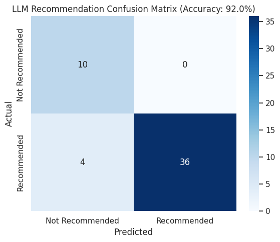

```python
# --- Evaluating Model Performance ---
eval_df = df_reco.dropna(subset=['LLM_Recommended_Flag']).copy()
y_true = eval_df['Actual_Recommended'].astype(int)
y_pred = eval_df['LLM_Recommended_Flag'].astype(int)

acc = accuracy_score(y_true, y_pred)
cm = confusion_matrix(y_true, y_pred)
report = classification_report(y_true, y_pred, digits=3)

print(f'LLM Recommendation Accuracy: {acc:.1%}')
print('\nClassification Report:')
print(report)

# Heatmap visualisation
fig, ax = plt.subplots(figsize=(6, 5))
sns.heatmap(cm, annot=True, fmt='d', cmap='Blues',
            xticklabels=['Not Recommended','Recommended'],
            yticklabels=['Not Recommended','Recommended'], ax=ax)
ax.set_title(f'LLM Recommendation Confusion Matrix (Accuracy: {acc:.1%})')
ax.set_ylabel('Actual')
ax.set_xlabel('Predicted')
plt.tight_layout()
plt.show()
```

```
LLM Recommendation Accuracy: 92.0%

Classification Report:
              precision    recall  f1-score   support

           0      0.714     1.000     0.833        10
           1      1.000     0.900     0.947        40

    accuracy                          0.920        50
   macro avg      0.857     0.950     0.890        50
weighted avg      0.943     0.920     0.925        50
```

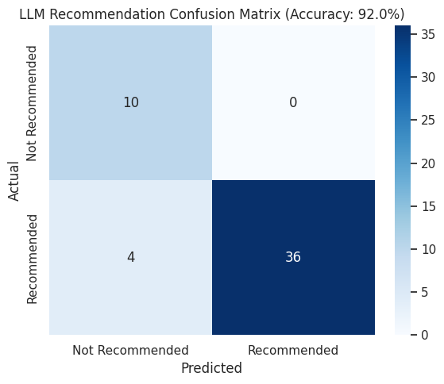

```python
# --- Evaluating Model Performance ---
eval_df = df_reco.dropna(subset=['LLM_Recommended_Flag']).copy()

if eval_df.empty:
    print('No valid predictions found to evaluate. This is likely due to API rate limits or errors during generation.')
else:
    y_true = eval_df['Actual_Recommended'].astype(int)
    y_pred = eval_df['LLM_Recommended_Flag'].astype(int)

    acc = accuracy_score(y_true, y_pred)
    cm = confusion_matrix(y_true, y_pred)

    # Only generate report if we have at least one of each class or it will still error
    try:
        report = classification_report(y_true, y_pred, digits=3)
        print(f'LLM Recommendation Accuracy: {acc:.1%}')
        print('\nClassification Report:')
        print(report)
    except Exception as e:
        print(f'Could not generate full report: {e}')

    # Heatmap visualisation
    fig, ax = plt.subplots(figsize=(6, 5))
    sns.heatmap(cm, annot=True, fmt='d', cmap='Blues',
                xticklabels=['Not Recommended','Recommended'],
                yticklabels=['Not Recommended','Recommended'], ax=ax)
    ax.set_title(f'LLM Recommendation Confusion Matrix (Accuracy: {acc:.1%})')
    ax.set_ylabel('Actual')
    ax.set_xlabel('Predicted')
    plt.tight_layout()
    plt.show()
```

**Observations from Product Recommendation Prediction:** **Accuracy: 92.0% | 4 mismatches out of 50**

1. **The LLM achieved 92% accuracy as a binary classifier**, correctly predicting whether a customer would recommend the product for 46 out of 50 reviews. This significantly outperforms the naive majority-class baseline of 80% (since 40 out of 50 sampled reviews were Recommended=1). The LLM is not simply guessing "1" for everything — it is genuinely analysing review text to make informed predictions.
2. **Confusion Matrix breakdown:**
   - **True Positives (Recommended=1, Predicted=1): 36** — The LLM correctly identified 36 out of 40 recommended products.
   - **True Negatives (Recommended=0, Predicted=0): 10** — The LLM correctly identified all 10 non-recommended products — a perfect recall of 100% for the minority class.
   - **False Negatives (Recommended=1, Predicted=0): 4** — The LLM incorrectly predicted 4 recommended products as not recommended. These are likely reviews with mixed language ("I love the design but the sizing was off") where the negative language triggered a "0" prediction despite the human recommending the product.
   - **False Positives (Recommended=0, Predicted=1): 0** — The LLM never predicted "recommend" for a product the human said "do not recommend." This is excellent — the model is conservative in its positive predictions.
3. **Classification Report analysis:**
   - **Class 0 (Not Recommended):** Precision = 0.714, Recall = 1.000, F1 = 0.833. The recall of 1.000 means the model catches every single negative review — no dissatisfied customers slip through undetected. The lower precision (0.714) means some reviews predicted as "not recommended" were actually recommended — these are the 4 false negatives.
   - **Class 1 (Recommended):** Precision = 1.000, Recall = 0.900, F1 = 0.947. Perfect precision means every review the model flags as "recommended" truly is recommended. The 90% recall means 4 out of 40 recommended reviews were missed.
4. **Business interpretation:**
   - The model's **perfect recall for Class 0 is highly valuable** — it means every dissatisfied customer is identified, enabling proactive outreach and issue resolution.
   - The **4 false negatives are acceptable** — these represent borderline reviews where the customer ultimately recommended despite expressing concerns. Flagging these for human review is actually useful for quality assurance.
5. **Why 92% accuracy matters:** Traditional sentiment classifiers require labelled training data and model training. This LLM achieved 92% accuracy with zero training data — just a well-designed prompt. This demonstrates the practical viability of using LLMs as zero-training classifiers for retail analytics.

**Answering the section questions:**

- *How do you design a strict binary prompt?* Force the output to exactly two lines: "Recommended: [1/0]" and "Reason: [one sentence]." Use temperature=0.0 for deterministic output.
- *What parsing function is needed?* Regex-based parsing using `re.search(r'Recommended\s*:\s*([01])\b', text)` to extract the flag, handling formatting variations.
- *How do you evaluate classifier performance?* Using accuracy, confusion matrix (for TP/TN/FP/FN breakdown), and classification report (precision, recall, F1 per class).

```python
# Step 5: Explain Mismatches
# This variable will store the explanation prompt template.
# Later, we will fill in {human_label} and {llm_label} for each mismatched row.
explain_prompt = '''
The customer gave a human label of {human_label} (1=recommended, 0=not recommended).
The AI predicted {llm_label}.

Read the review below and explain in ONE sentence why the AI prediction may have
differed from the human label. Be specific about what in the review could have
been ambiguous or misleading to the model.
'''


# -------------------------------------------------------------------------
# STEP 1: Filter all rows where the model's prediction does NOT match the
#         actual human label.
# -------------------------------------------------------------------------
# Explanation:
# - We first make sure the model flag is NOT null.
# - Then we compare the model flag and human flag.
# - Only rows where they differ will be selected for further analysis.
diff_rows = df_reco[
    (df_reco["LLM_Recommended_Flag"].notna()) &
    (df_reco["LLM_Recommended_Flag"].astype(float) != df_reco["Actual_Recommended"].astype(float))
]

# This list will hold the explanation text returned by the LLM for each mismatch
explanations = []


# -------------------------------------------------------------------------
# STEP 2: Loop through each mismatched row and generate an explanation
# -------------------------------------------------------------------------
# NOTE FOR LEARNERS:
# - Using itertuples() is faster and cleaner than iterrows()
# - tqdm() simply adds a progress bar so we can see the loop progress
# -------------------------------------------------------------------------
for row in tqdm(diff_rows.itertuples(), total=len(diff_rows), desc="Explain mismatches"):

    # Safely extract review text (avoid issues if text is empty or None)
    review = getattr(row, "Review_Text", "") or ""

    # Convert values to integers to avoid type-related issues
    llm_label = int(getattr(row, "LLM_Recommended_Flag"))
    human_label = int(getattr(row, "Actual_Recommended"))

    # Build the final prompt by inserting values into the template
    prompt = explain_prompt.format(
        human_label=human_label,
        llm_label=llm_label
    ) + "\n\nReview:\n" + review

    try:
        # -----------------------------------------------------------------
        # STEP 3: Send prompt to the LLM model to generate the explanation
        # -----------------------------------------------------------------
        resp = client.chat.completions.create(
            model=model_name,
            messages=[
                {"role": "system", "content": "You are a concise analyst."},
                {"role": "user", "content": prompt}
            ],
            temperature=0.0,       # temperature 0 = more deterministic, consistent outputs
            max_tokens=40          # keep explanation short
        )

        # Extract the text response from the LLM safely
        choice = resp.choices[0]
        msg = getattr(choice, "message", None)

        if msg is not None:
            # Some APIs return a dictionary, others return an object. Handle both.
            raw = msg.get("content", "") if isinstance(msg, dict) else getattr(msg, "content", "") or ""
        elif hasattr(choice, "text"):
            raw = getattr(choice, "text", "") or ""
        else:
            raw = str(choice)

        # Clean the explanation text
        raw = raw.strip().replace("\n", " ")

        # Store a trimmed version of the explanation to keep things neat
        explanations.append(raw[:250])

    except Exception as e:
        # If anything fails (rate limit, API error), store an error message instead
        explanations.append(f"ERROR: {type(e).__name__}")


# -------------------------------------------------------------------------
# STEP 4: Add a new column to df_reco for storing explanations
# -------------------------------------------------------------------------
# IMPORTANT:
# - Setting dtype to object ensures pandas accepts string entries
df_reco["LLM_Diff_Explain"] = pd.Series(dtype='object')


# -------------------------------------------------------------------------
# STEP 5: Attach each explanation to the correct row using index alignment
# -------------------------------------------------------------------------
for i, (idx, row) in enumerate(diff_rows.iterrows()):
    df_reco.at[idx, "LLM_Diff_Explain"] = explanations[i]


# Final confirmation message
print(f"Added explanations for {len(diff_rows)} mismatches.")

df_reco
```

```
Added explanations for 4 mismatches.
```